# NDI and SVI

Primary Programmer: Jiayi Zhou

Contributors: Stephen P. Uong, Jeanette A. Stingone

10/27/2021

## Aim

In this RMD, we have documented the process of constructing an Neighborhood Deprivation Index (NDI) following a developed method. We have also imported the Social Vulnerability Index (SVI) data from the CDC and tested the correlation between NDI and the SVI on the census-tract level in the New York City.

## Setup

We set the working directory to one folder up from the RMarkdown file.

```r
knitr::opts_knit$set(root.dir = '..')
```

```r
knitr::opts_chunk$set(echo = TRUE)
options(tigris_class = "sf")
```

```r
library(devtools)
```

```r
library(ggbiplot)
library(stats)
library(factoextra)
library(cluster)

library(tidycensus)
library(tidyverse)
library(psych)
library(tigris)
library(sf)
library(Amelia)
library(patchwork)
library(rgdal)
library(viridis)
library(wesanderson)
```

## NDI Associated Variables:

Based on a review of literature, 23 census variables that have been used consistently to approximate neighborhood-level environments for possible inclusion in the deprivation index.

#### Candidate SEP variables (n = 23)

Source: US Census American Communities Survey (2015-2019)

**Education (among adults aged > 25)**  
% < High School  
% BA or more

**Employment (among adult labor force, aged 20-64)**  
% unemployed  
% males in labor force  
% females in labor force

**Housing**  
% renter occupied (among occupied units)  
% vacant housing units (among total housing units)  
% crowded (> 1 occupant per room, among occupied housing units)

**Occupation (among full-time, year-round civilian employed population)**  
% adults in management or professional occupations

**Racial composition**  
% African American (non-Hispanic)  
% non-White (calculated as 1 - % non-Hispanic White population)  
% Hispanic

**Residential Stability**  
% living in the same house one year ago  
% Foreign-born  
% not a U.S. citizen

**Language**  
% speak English less than “very well” (among pop > 5 years old who speak a language other than English at home)

#### Check the ACS variables

```r
acs_19 <- load_variables(2019, "acs5", cache = TRUE)

#View(acs_19)
```

#### Write out All the Variables Names that will be needed from the ACS:

```r
edu_belowHS_male = sprintf("B15002_%0.3d",seq(3, 10, by = 1))
edu_belowHS_female = sprintf("B15002_%0.3d",seq(20, 27, by = 1))
edu_BA_more = c("B15002_015","B15002_016","B15002_017","B15002_018","B15002_032","B15002_033","B15002_034","B15002_035")
edu_var = c(edu_belowHS_female, edu_belowHS_male, edu_BA_more,"B15002_002", "B15002_019")

unempl_male = sprintf("B23001_%0.3d",seq(15, 71, by = 7))
unempl_female = sprintf("B23001_%0.3d",seq(101, 157, by = 7))
labor_force_male = sprintf("B23001_%0.3d",seq(11, 67, by = 7))
labor_force_female = sprintf("B23001_%0.3d",seq(97, 153, by = 7))
unempl_var = c("B23001_002", "B23001_088","B23001_001","B23001_003","B23001_089",
               labor_force_female,labor_force_male, unempl_male, unempl_female)


housing_var = c("B25003_001","B25002_001","B25002_003", "B25003_003",
                "B25014_001", "B25014_005", "B25014_006", "B25014_007",
                "B25014_011", "B25014_012", "B25014_013", "B25070_007",
                "B25070_008","B25070_009","B25070_010","B25070_011","B25070_001")

occup_var = c("C24010_001", "C24010_003","C24010_040")

poverty_var = c("B17010_001", "B17010_002",
                "B11005_007","B11005_010","B11005_001",
                "B19057_001","B19057_002",
                "B99221_002","B99221_001",
                "B19013_001",
                "B19001_001", "B19001_002",
                "B19001_003", "B19001_004",
                "B19001_005", "B19001_006", "B19001_007")

racial_var = c("B03002_004", "B03002_003", "B03002_012", "B03002_001")

stability_var = c("B07007_001", "B07007_006", "B07007_003", "B07007_005")

language_var = c("B16005_001","B16005_007", "B16005_008","B16005_012","B16005_013",
                 "B16005_017", "B16005_018", "B16005_022", "B16005_023",
                 "B16005_029", "B16005_030", "B16005_034", "B16005_035",
                 "B16005_039", "B16005_040", "B16005_044", "B16005_045")

c_var = c(edu_var, unempl_var, housing_var, occup_var, poverty_var, racial_var,stability_var,language_var)
```

#### Pulling Census Data

We used an exclusion list to filter out the census tracts that does not pass the inclusion criteria. Of the original 2,167 census tracts in New York City (NYC), we excluded 51 tracts that had a population of less than twenty people and 30 tracts that had a population of at least twenty people but had at least one missing feature in the calculation of the NVI or the Neighborhood Deprivation Index (described later). The majority of the 30 census tracts were non-residential areas, such construction sites, parks, and areas with institutions. As a result, we included 2,086 census tracts in our development of the NVI.

```r
exclusion_table = read.csv("data/processed/EXCLUSION_LIST_20210628.csv")

view(exclusion_table)
```

#### Data Transformation

Considering the final NDI should be an index with the higher value indicating more deprivation, the value of the candidate variables should show the same pattern. Thus, we reverse coded measures that originally had smaller value associated with deprivation, such as: * percent population with a college degree or higher * percent male and female in labor force * percent population in mangement * percent non-White population * percent living in the same house for the past year By doing this reverse coding, we can ensure that they were pointing in the same direction as the other candidate variables.

We also reverse coded and log transformed median household income to ensure normal distribution.

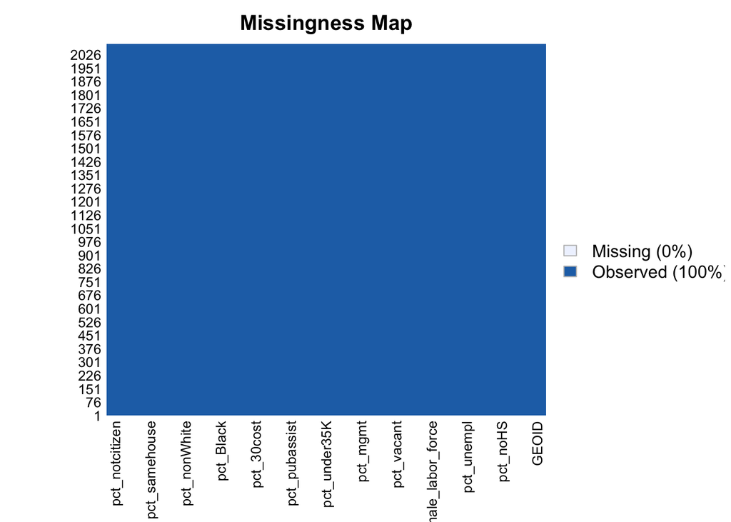

```r
#pulling data
nyc_data =
  get_acs(geography = "tract", variables =c_var,
                    state = "NY",
                    county = c('Bronx County', 'Kings County',
                        'New York County', 'Queens County', 'Richmond County'),
                    year = 2019,
                    output = "wide")
total_left = exclusion_table %>% filter(flag_exclude_FINAL == 0) %>% select(GEOID)

total_left = as.vector(total_left$GEOID)

nyc_acs_data = nyc_data %>%
  filter(GEOID %in% total_left) %>%
  mutate(pct_noHS =
           (B15002_003E+B15002_004E+B15002_005E+B15002_006E+B15002_007E+B15002_008E+B15002_009E+B15002_010E+B15002_020E+B15002_021E+B15002_022E+B15002_023E+B15002_024E+B15002_025E+B15002_026E+B15002_027E)/(B15002_002E+B15002_019E),
         pct_BAmore =
           1-((B15002_015E+B15002_016E+B15002_017E+B15002_018E+B15002_032E+B15002_033E+B15002_034E+B15002_035E)/(B15002_002E+B15002_019E)),
         pct_unempl =
           (B23001_015E+B23001_022E+B23001_029E+B23001_036E+
            B23001_043E+B23001_050E+B23001_057E+B23001_064E+
            B23001_071E+B23001_101E+B23001_108E+B23001_115E+B23001_122E+
            B23001_129E+B23001_136E+B23001_143E+B23001_150E+B23001_157E)/
           (B23001_001E-B23001_003E-B23001_089E),
         pct_male_labor_force =
           1-((B23001_011E+B23001_018E+B23001_025E+B23001_032E+B23001_039E+B23001_046E+B23001_053E+B23001_060E+B23001_067E)/(B23001_002E-B23001_003E)),
         pct_female_labor_force =
           1-((B23001_097E+B23001_104E+B23001_111E+B23001_118E+B23001_125E+B23001_132E+B23001_139E+B23001_146E+B23001_153E)/(B23001_088E-B23001_089E)),
         pct_rented =
           B25003_003E/B25003_001E,
         pct_vacant = B25002_003E/B25002_001E,
         pct_crowded = (B25014_005E+B25014_006E+B25014_007E+B25014_011E+B25014_012E+B25014_013E)/B25014_001E,
         pct_mgmt = 1-((C24010_003E+C24010_040E)/C24010_001E),
         pct_poverty = B17010_002E/B17010_001E,
         pct_FHH = (B11005_007E+B11005_010E)/B11005_001E,
         pct_under35K = (B19001_002E+B19001_003E+B19001_004E+B19001_005E+B19001_006E+B19001_007E)/B19001_001E,
         pct_pubassist = B19057_002E/B19057_001E,
         pct_foodstamp = B99221_002E/B99221_001E,
         median_HH_income = -log(B19013_001E),
         pct_30cost =
           (B25070_007E+B25070_008E+B25070_009E+B25070_010E+B25070_011E)/B25070_001E,
         pct_Black = B03002_004E/B03002_001E,
         pct_nonWhite = 1-(B03002_003E/B03002_001E),
         pct_Hispanic = B03002_012E/B03002_001E,
         pct_E_notwell = (B16005_007E+B16005_008E+B16005_012E+B16005_013E+B16005_017E+B16005_018E+B16005_022E+B16005_023E+B16005_029E+B16005_030E+B16005_034E+B16005_035E+B16005_039E+B16005_040E+B16005_044E+B16005_045E)/B16005_001E,
         pct_samehouse = -B07007_006E/B07007_001E,
         pct_foreignborn = B07007_003E/B07007_001E,
         pct_notcitizen = B07007_005E/B07007_001E)%>%
  mutate(NAME = gsub(" County, New York", "", NAME)) %>%
  select(GEOID, NAME,
         pct_noHS,pct_BAmore,
         pct_unempl, pct_male_labor_force,pct_female_labor_force,
         pct_rented, pct_vacant,pct_crowded,
         pct_mgmt, pct_poverty, pct_under35K, pct_FHH, pct_pubassist, pct_foodstamp,pct_30cost,
         median_HH_income,
         pct_Black,pct_Hispanic,pct_nonWhite,pct_E_notwell,
         pct_samehouse, pct_foreignborn, pct_notcitizen)

missmap(nyc_acs_data)
nyc_acs_data = nyc_acs_data %>% drop_na()

missmap(nyc_acs_data)
```

## Step 1: City Wide: Dimensionality Reduction

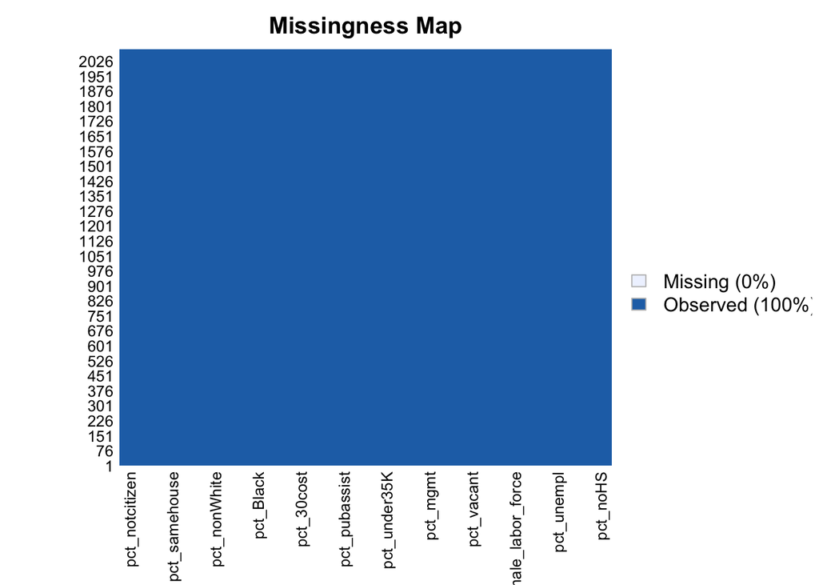

```r
values =
  nyc_acs_data %>%
  select(pct_noHS,pct_BAmore,
         pct_unempl, pct_male_labor_force,pct_female_labor_force,
         pct_rented, pct_vacant,pct_crowded,
         pct_mgmt, pct_poverty, pct_under35K, pct_FHH, pct_pubassist, pct_foodstamp,pct_30cost,
         median_HH_income,
         pct_Black,pct_Hispanic,pct_nonWhite,pct_E_notwell,
         pct_samehouse, pct_foreignborn, pct_notcitizen)

missmap(values)
```

```r
#values[values == 0] <- NA
```

```r
# compute variance of each variable
# will see standarization is needed
apply(values, 2, var, na.rm = TRUE)
```

```
##               pct_noHS             pct_BAmore             pct_unempl
##           0.0124689839           0.0423459510           0.0005708777
##   pct_male_labor_force pct_female_labor_force             pct_rented
##           0.0100878240           0.0094271791           0.0644051824
##             pct_vacant            pct_crowded               pct_mgmt
##           0.0038407928           0.0054021429           0.0190837267
##            pct_poverty           pct_under35K                pct_FHH
##           0.0131407729           0.0233332561           0.0061293516
##          pct_pubassist          pct_foodstamp             pct_30cost
##           0.0018832185           0.0004750119           0.0170706887
##       median_HH_income              pct_Black           pct_Hispanic
##           0.2488333248           0.0804108599           0.0498139656
##           pct_nonWhite          pct_E_notwell          pct_samehouse
##           0.0842399560           0.0114500387           0.0038626993
##        pct_foreignborn         pct_notcitizen
##           0.0229380830           0.0083207011
```

```r
# create new data frame with centered variables
scaled_df = apply(values, 2, scale)
#scaled_df[is.na(scaled_df)] = 0  #assign 0 to NA values,.
head(scaled_df)
```

```
##       pct_noHS pct_BAmore pct_unempl pct_male_labor_force
## [1,] 1.0782972  0.8985422  0.5281842           -0.7419128
## [2,] 0.5402499  1.0544374 -0.0109769           -0.2287875
## [3,] 0.6353121  0.6240864 -0.9241071            0.1148664
## [4,] 2.2085674  1.4786889 -0.9503552           -1.5266710
## [5,] 2.1979945  1.3951581 -0.6350518           -0.9833780
## [6,] 3.1713313  1.5321195 -0.8059469           -0.7709334
##      pct_female_labor_force  pct_rented pct_vacant pct_crowded    pct_mgmt
## [1,]              0.8630653  0.10273291  2.5277316   2.0805667  1.16877692
## [2,]             -0.6821145 -0.06607182  3.7627546   0.8201019  0.26335038
## [3,]              1.3870467 -1.49004026  3.7797425   0.0659844 -0.01645666
## [4,]             -0.9888253  0.29529758  0.8697970   2.9782024  1.55823598
## [5,]             -0.9949257  0.48844883 -0.9638729   4.3984021  1.42186280
## [6,]              0.1223694  0.22029157 -1.0242716   2.8985270  1.39666889
##      pct_poverty pct_under35K     pct_FHH pct_pubassist pct_foodstamp
```

[output cut: 20 more lines]

```r
# Calculate eigenvalues & eigenvectors
ndi_var.cov = cov(scaled_df)
ndi_var.eigen = eigen(ndi_var.cov) #PC1-5
str(ndi_var.eigen)
```

```
## List of 2
##  $ values : num [1:23] 8.48 2.99 2.28 1.96 1.06 ...
##  $ vectors: num [1:23, 1:23] -0.295 -0.294 -0.171 -0.075 -0.106 ...
##  - attr(*, "class")= chr "eigen"
```

```r
pca_firstcitywide_rotated <- psych::principal(scaled_df, rotate="varimax", nfactors=5, scores=TRUE)
print(pca_firstcitywide_rotated$loadings[,1:5])
```

```
##                                RC1          RC2          RC4          RC3
## pct_noHS                0.61527462  0.566948698  0.169841978  0.248296461
## pct_BAmore              0.39698999  0.408096651  0.578594365  0.436887560
## pct_unempl              0.53171410 -0.027728048  0.391431508 -0.137653957
## pct_male_labor_force    0.19137393 -0.314902706  0.032263282  0.736745517
## pct_female_labor_force  0.11638628  0.091848798 -0.171990798  0.846381979
## pct_rented              0.79058819  0.203223761 -0.114246884 -0.330677996
## pct_vacant             -0.11436198 -0.089424603 -0.299169219 -0.143838659
## pct_crowded             0.31501510  0.680383548  0.021387783  0.004907243
## pct_mgmt                0.33306427  0.427121797  0.631791081  0.375081609
## pct_poverty             0.86949117  0.141926373  0.105081241  0.247138641
## pct_under35K            0.86960827  0.133898606  0.125763522  0.330936555
## pct_FHH                 0.61647565 -0.007187623  0.621223378  0.051709766
## pct_pubassist           0.73835676 -0.035376720  0.281006109  0.160333319
## pct_foodstamp           0.04685448  0.126264843  0.218159586  0.131223251
## pct_30cost              0.21056643  0.346392601  0.237465674  0.455299825
## median_HH_income        0.79779282  0.244699015  0.257295104  0.372109945
## pct_Black               0.07317824 -0.294548192  0.849932648 -0.030132368
## pct_Hispanic            0.60119599  0.424952652  0.083817267 -0.069471060
## pct_nonWhite            0.34539632  0.358163171  0.762503137 -0.022905420
## pct_E_notwell           0.28273597  0.835243778 -0.173693433  0.196254083
## pct_samehouse           0.12598784 -0.119121002 -0.430285308 -0.580619342
## pct_foreignborn        -0.19750215  0.831839526  0.214079024  0.072786428
## pct_notcitizen          0.12342721  0.893039623  0.007714563 -0.187011853
##                                 RC5
## pct_noHS               -0.134454860
## pct_BAmore             -0.129329461
## pct_unempl             -0.119233956
## pct_male_labor_force    0.097417891
## pct_female_labor_force  0.003081202
## pct_rented              0.133706424
## pct_vacant              0.653074257
## pct_crowded             0.095338653
## pct_mgmt               -0.131917260
## pct_poverty             0.021897476
## pct_under35K            0.043552766
## pct_FHH                -0.076010800
## pct_pubassist          -0.023621163
## pct_foodstamp           0.659642767
## pct_30cost              0.091233422
## median_HH_income        0.006000058
## pct_Black               0.143870814
## pct_Hispanic           -0.212066216
## pct_nonWhite           -0.011484074
## pct_E_notwell          -0.102250419
## pct_samehouse           0.211044483
## pct_foreignborn         0.052332959
## pct_notcitizen          0.041593836
```

**Retained in the initial city-wide**  
pct_unempl,  
pct_rented,pct_crowded,  
pct_poverty,pct_under35K,pct_pubassist,median_HH_income,  
pct_nonWhite,pct_E_notwell

## Step 2: Stratified PCA (5 boroughs)

#### Bronx County

```r
values_bronx=
  nyc_acs_data %>%
  filter(str_detect(GEOID, "^36005" )) %>%
  select(pct_noHS,pct_BAmore,
pct_unempl,pct_male_labor_force, pct_female_labor_force,
pct_rented,pct_vacant,pct_crowded,
pct_mgmt,
pct_poverty,pct_under35K,pct_FHH,pct_pubassist,pct_foodstamp,pct_30cost,median_HH_income,
pct_Black, pct_Hispanic,pct_nonWhite,pct_E_notwell,
pct_samehouse,pct_foreignborn, pct_notcitizen)

#values_bronx[values_bronx == 0] <- NA
```

```r
# compute variance of each variable
# will see standarization is needed
apply(values_bronx, 2, var, na.rm = TRUE)
```

```r
# create new data frame with centered variables
scaled_df_b = apply(values_bronx, 2, scale)
#scaled_df_b[is.na(scaled_df_b)] = 0  #assign 0 to NA values, no variance? not sure if ok.
head(scaled_df_b)
```

```r
# Calculate eigenvalues & eigenvectors
ndi_var_b.cov = cov(scaled_df_b)
ndi_var_b.eigen = eigen(ndi_var_b.cov) #PC5
str(ndi_var_b.eigen)
```

```r
pca_bronx_rotated <- psych::principal(scaled_df_b, rotate="varimax", nfactors=5, scores=TRUE)
print(pca_bronx_rotated$loadings[,1:5])
```

[output not shown]

**Retain: Bronx**  
pct_noHS,pct_BAmore,  
pct_rented,  
pct_mgmt,  
pct_poverty,pct_under35K,pct_FHH,pct_pubassist,pct_30cost,median_HH_income,  
pct_notcitizen

#### Kings County

```r
values_kings=
  nyc_acs_data %>%
  filter(str_detect(GEOID, "^36047" )) %>%
  select(pct_noHS,pct_BAmore,
pct_unempl,pct_male_labor_force, pct_female_labor_force,
pct_rented,pct_vacant,pct_crowded,
pct_mgmt,
pct_poverty,pct_under35K,pct_FHH,pct_pubassist,pct_foodstamp,pct_30cost,median_HH_income,
pct_Black, pct_Hispanic,pct_nonWhite,pct_E_notwell,
pct_samehouse,pct_foreignborn, pct_notcitizen)

#values_kings[values_kings == 0] <- NA
```

```r
# compute variance of each variable
# will see standarization is needed
apply(values_kings, 2, var, na.rm = TRUE)
```

```r
# create new data frame with centered variables
scaled_df_k = apply(values_kings, 2, scale)
#scaled_df_k[is.na(scaled_df_k)] = 0  #assign 0 to NA values, no variance? not sure if ok.
head(scaled_df_k)
```

```r
# Calculate eigenvalues & eigenvectors
ndi_var_k.cov = cov(scaled_df_k)
ndi_var_k.eigen = eigen(ndi_var_k.cov) #PC5
str(ndi_var_k.eigen)
```

```r
pca_kings_rotated <- psych::principal(scaled_df_k, rotate="varimax", nfactors=5, scores=TRUE)
print(pca_kings_rotated$loadings[,1:5])
```

[output not shown]

**Retain: Kings**  
pct_unempl,  
pct_rented,  
pct_poverty,pct_pubassist,  
pct_Hispanic

#### New York County

```r
values_NY=
  nyc_acs_data %>%
  filter(str_detect(GEOID, "^36061" )) %>%
  select(pct_noHS,pct_BAmore,
pct_unempl,pct_male_labor_force, pct_female_labor_force,
pct_rented,pct_vacant,pct_crowded,
pct_mgmt,
pct_poverty,pct_under35K,pct_FHH,pct_pubassist,pct_foodstamp,pct_30cost,median_HH_income,
pct_Black, pct_Hispanic,pct_nonWhite,pct_E_notwell,
pct_samehouse,pct_foreignborn, pct_notcitizen)

  missmap(values_NY)
#values_NY[values_NY == 0] <- NA
```

```r
# compute variance of each variable
# will see standarization is needed
apply(values_NY, 2, var, na.rm = TRUE)
```

```r
# create new data frame with centered variables
scaled_df_ny = apply(values_NY, 2, scale)
#scaled_df_ny[is.na(scaled_df_ny)] = 0  #assign 0 to NA values, no variance? not sure if ok.
head(scaled_df_ny)
```

```r
# Calculate eigenvalues & eigenvectors
ndi_var_ny.cov = cov(scaled_df_ny)
ndi_var_ny.eigen = eigen(ndi_var_ny.cov) #PC4
str(ndi_var_ny.eigen)
```

```r
pca_ny_rotated <- psych::principal(scaled_df_ny, rotate="varimax", nfactors=4, scores=TRUE)
print(pca_ny_rotated$loadings[,1:4])
```

[output not shown]

**Retain: New York**  
pct_BAmore,  
pct_unempl,  
pct_crowded,  
pct_mgmt,  
pct_poverty,pct_FHH,pct_pubassist,median_HH_income,  
pct_Black,pct_nonWhite

#### Queens County

```r
values_queens=
  nyc_acs_data %>%
  filter(str_detect(GEOID, "^36081" )) %>%
  select(pct_noHS,pct_BAmore,
pct_unempl,pct_male_labor_force, pct_female_labor_force,
pct_rented,pct_vacant,pct_crowded,
pct_mgmt,
pct_poverty,pct_under35K,pct_FHH,pct_pubassist,pct_foodstamp,pct_30cost,median_HH_income,
pct_Black, pct_Hispanic,pct_nonWhite,pct_E_notwell,
pct_samehouse,pct_foreignborn, pct_notcitizen)

  missmap(values_queens)
#values_queens[values_queens == 0] <- NA
```

```r
# compute variance of each variable
# will see standarization is needed
apply(values_queens, 2, var, na.rm = TRUE)
```

```r
# create new data frame with centered variables
scaled_df_q = apply(values_queens, 2, scale)
#scaled_df_q[is.na(scaled_df_q)] = 0  #assign 0 to NA values, no variance? not sure if ok.
head(scaled_df_q)
```

```r
# Calculate eigenvalues & eigenvectors
ndi_var_q.cov = cov(scaled_df_q)
ndi_var_q.eigen = eigen(ndi_var_q.cov) #PC6
str(ndi_var_q.eigen)
```

```r
pca_queens_rotated <- psych::principal(scaled_df_q, rotate="varimax", nfactors=6, scores=TRUE)
print(pca_queens_rotated$loadings[,1:6])
```

[output not shown]

**Retain: Queens**  
pct_noHS,  
pct_crowded,  
pct_poverty,median_HH_income,  
pct_Hispanic,pct_E_notwell,  
pct_foreignborn, pct_notcitizen

#### Richmond County

```r
values_Richmond=
  nyc_acs_data %>%
  filter(str_detect(GEOID, "^36085" )) %>%
  select(pct_noHS,pct_BAmore,
pct_unempl,pct_male_labor_force, pct_female_labor_force,
pct_rented,pct_vacant,pct_crowded,
pct_mgmt,
pct_poverty,pct_under35K,pct_FHH,pct_pubassist,pct_foodstamp,pct_30cost,median_HH_income,
pct_Black, pct_Hispanic,pct_nonWhite,pct_E_notwell,
pct_samehouse,pct_foreignborn, pct_notcitizen)
#values_Richmond[values_Richmond == 0] <- NA
```

```r
# compute variance of each variable
# will see standarization is needed
apply(values_Richmond, 2, var, na.rm = TRUE)
```

```r
# create new data frame with centered variables
scaled_df_r = apply(values_Richmond, 2, scale)
#scaled_df_r[is.na(scaled_df_r)] = 0  #assign 0 to NA values, no variance? not sure if ok.
head(scaled_df_r)
```

```r
# Calculate eigenvalues & eigenvectors
ndi_var_r.cov = cov(scaled_df_r)
ndi_var_r.eigen = eigen(ndi_var_r.cov) #PC6
str(ndi_var_r.eigen)
```

```r
pca_richmond_rotated <- psych::principal(scaled_df_r, rotate="varimax", nfactors=6, scores=TRUE)
print(pca_richmond_rotated$loadings[,1:6])
```

[output not shown]

**Retain: Richmond**  
pct_male_labor_force,  
pct_rented,pct_vacant,pct_crowded,  
pct_poverty,pct_under35K,pct_FHH,pct_pubassist,median_HH_income,  
pct_Black,pct_E_notwell,  
pct_notcitizen

## Succesive PCA Summary:

I have tallied all variables that retained from each step here. To see a more detailed table, please refer to the supplemental Table 1 of the paper.

pct_unempl,  
pct_rented,pct_crowded,  
pct_poverty,pct_under35K,pct_pubassist,median_HH_income,  
pct_nonWhite,pct_E_notwell

*After doing the stratified PAC, we have the following variables loaded strongly borough-level PCA solutions:  
**Bronx**  
pct_noHS,pct_BAmore,  
pct_rented,  
pct_mgmt,  
pct_poverty,pct_under35K,pct_FHH,pct_pubassist,pct_30cost,median_HH_income,  
pct_notcitizen

**Kings**  
pct_unempl,  
pct_rented,  
pct_poverty,pct_pubassist,  
pct_Hispanic

**New York**  
pct_BAmore,  
pct_unempl,  
pct_crowded,  
pct_mgmt,  
pct_poverty,pct_FHH,pct_pubassist,median_HH_income,  
pct_Black,pct_nonWhite

**Queens**  
pct_noHS,  
pct_crowded,  
pct_poverty,median_HH_income,  
pct_Hispanic,pct_E_notwell,  
pct_foreignborn, pct_notcitizen

**Richmond**  
pct_male_labor_force,  
pct_rented,pct_vacant,pct_crowded,  
pct_poverty,pct_under35K,pct_FHH,pct_pubassist,median_HH_income,  
pct_Black,pct_E_notwell,  
pct_notcitizen

**more then 2 boroughs**:  
pct_noHS,pct_BAmore,  
pct_unempl,  
pct_rented,pct_crowded,  
pct_mgmt,  
pct_poverty,pct_under35K,pct_FHH,pct_pubassist,median_HH_income,  
pct_Hispanic, pct_Black, pct_E_notwell  
pct_notcitizen

**less then 0.16:**  
bronx:(pct_Black)  
kings:(pct_notcitizen)  
queens:(pct_unempl,pct_FHH,pct_pubassist)

**Variables that should be included in the second city-wide:(only > 0.4 or < -0.4 in one component)**  
*from stratified*  
pct_noHS,pct_BAmore,  
pct_rented,pct_crowded,  
pct_mgmt,  
pct_poverty,pct_under35K,median_HH_income,  
pct_Hispanic, pct_E_notwell  
+  
*from first city-wide*  
pct_unempl,  
pct_rented,pct_crowded,  
pct_poverty,pct_under35K,pct_pubassist,median_HH_income,  
pct_nonWhite,pct_E_notwell

**NEW TOTAL**  
pct_noHS,pct_BAmore,  
pct_unempl，  
pct_rented,pct_crowded,  
pct_mgmt,  
pct_poverty,pct_under35K,pct_pubassist, median_HH_income,  
pct_nonWhite,pct_Hispanic, pct_E_notwell

## Step 3: Second City-wide:

1. Repeat steps b-f described in the first city-wide PCA process (used the same inclusion and exclusion criteria as the first city wide PAC since cannot find description on what Messer or Shmool did):

```r
values_s =
  nyc_acs_data %>%
  select(pct_noHS,pct_BAmore,
pct_unempl,
pct_rented,pct_crowded,
pct_mgmt,
pct_poverty,pct_under35K,pct_pubassist, median_HH_income,
pct_nonWhite,pct_Hispanic, pct_E_notwell)

missmap(values_s)
#values[values == 0] <- NA(0% are still meaningful)
```

```r
# compute variance of each variable
# will see standarization is needed
apply(values_s, 2, var, na.rm = TRUE)
```

```r
# create new data frame with centered variables
scaled_df_s = apply(values_s, 2, scale)
#scaled_df[is.na(scaled_df)] = 0  #assign 0 to NA values,.
head(scaled_df_s)
```

```r
# Calculate eigenvalues & eigenvectors
ndi_var_s.cov = cov(scaled_df_s)
ndi_var_s.eigen = eigen(ndi_var_s.cov) #PC3
str(ndi_var_s.eigen)
```

```r
pca_secondcitywide_rotated <- psych::principal(scaled_df_s, rotate="varimax", nfactors=3, scores=TRUE)
print(pca_secondcitywide_rotated$loadings[,1:3])
```

[output not shown]

**after omition:**  
pct_BAmore,  
pct_unempl，  
pct_mgmt,  
pct_poverty,pct_under35K,pct_pubassist,  
pct_nonWhite

The final 7 features of deprivation were used to re-ran the final PCA and create the final NDI.

## Step 4: Final City-Wide PCA

Final Index construction (starts with 7 variables: % BA or more,% unemployed, % adults in management or professional occupations ,% households in poverty (< 200% Federal Poverty Line),% Families w/ annual income < $35,000 (2019 inflation-adjusted),% households w/ public assistance income,% non-White)

1. Re-run the PCA process with the 7 variables
2. Extract the un-rotated loading in the first component as the NDI

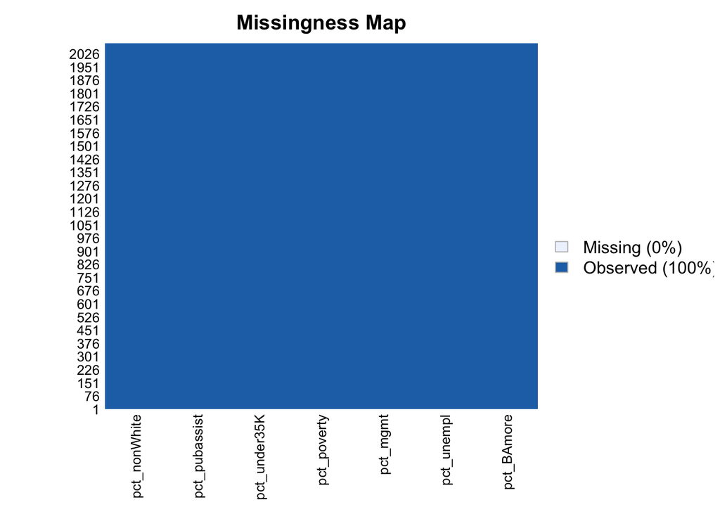

```r
# create new data frame with centered variables
NDI_df = nyc_acs_data %>%
  select(pct_BAmore,
pct_unempl,
pct_mgmt,
pct_poverty,pct_under35K,pct_pubassist,
pct_nonWhite)

missmap(NDI_df)
```

```r
scaled_ndi_df = apply(NDI_df, 2, scale)
#scaled_ndi_df[is.nan(scaled_ndi_df)] = 0  #assign 0 to NA values, no variance? not sure if ok.
head(scaled_ndi_df)
```

```
##      pct_BAmore pct_unempl    pct_mgmt pct_poverty pct_under35K pct_pubassist
## [1,]  0.8985422  0.5281842  1.16877692  -0.3099203  0.311129695    0.46050588
## [2,]  1.0544374 -0.0109769  0.26335038   0.9018043 -0.483375544   -0.05731521
## [3,]  0.6240864 -0.9241071 -0.01645666  -0.6722409 -0.613949995   -0.11383015
## [4,]  1.4786889 -0.9503552  1.55823598  -0.6050456 -0.663519264   -0.61471608
## [5,]  1.3951581 -0.6350518  1.42186280  -0.2580814 -0.317747703   -0.84770477
## [6,]  1.5321195 -0.8059469  1.39666889   0.7728494  0.003072059    0.32722513
##      pct_nonWhite
## [1,]    0.9933440
## [2,]    0.9773274
## [3,]    1.0566920
## [4,]    1.0895477
## [5,]    1.0740447
## [6,]    1.0543694
```

```r
summary(NDI_df)
```

```
##    pct_BAmore       pct_unempl         pct_mgmt       pct_poverty
##  Min.   :0.0301   Min.   :0.00000   Min.   :0.2459   Min.   :0.00000
##  1st Qu.:0.5469   1st Qu.:0.02100   1st Qu.:0.6781   1st Qu.:0.05105
##  Median :0.6926   Median :0.03211   Median :0.7802   Median :0.10912
##  Mean   :0.6419   Mean   :0.03761   Mean   :0.7489   Mean   :0.13956
##  3rd Qu.:0.7925   3rd Qu.:0.04861   3rd Qu.:0.8503   3rd Qu.:0.20113
##  Max.   :0.9761   Max.   :0.18698   Max.   :0.9895   Max.   :0.63501
##   pct_under35K    pct_pubassist      pct_nonWhite
##  Min.   :0.0000   Min.   :0.00000   Min.   :0.01082
##  1st Qu.:0.1917   1st Qu.:0.01354   1st Qu.:0.42183
##  Median :0.2706   Median :0.03177   Median :0.76696
##  Mean   :0.3052   Mean   :0.04474   Mean   :0.67907
##  3rd Qu.:0.3931   3rd Qu.:0.06269   3rd Qu.:0.95805
##  Max.   :0.8773   Max.   :0.37303   Max.   :1.00000
```

```r
summary(scaled_ndi_df)
```

```
##    pct_BAmore        pct_unempl         pct_mgmt        pct_poverty
##  Min.   :-2.9733   Min.   :-1.5743   Min.   :-3.6409   Min.   :-1.2175
##  1st Qu.:-0.4620   1st Qu.:-0.6953   1st Qu.:-0.5126   1st Qu.:-0.7721
##  Median : 0.2460   Median :-0.2304   Median : 0.2270   Median :-0.2656
##  Mean   : 0.0000   Mean   : 0.0000   Mean   : 0.0000   Mean   : 0.0000
##  3rd Qu.: 0.7318   3rd Qu.: 0.4603   3rd Qu.: 0.7344   3rd Qu.: 0.5371
##  Max.   : 1.6240   Max.   : 6.2515   Max.   : 1.7420   Max.   : 4.3220
##   pct_under35K     pct_pubassist      pct_nonWhite
##  Min.   :-1.9982   Min.   :-1.0310   Min.   :-2.3024
##  1st Qu.:-0.7432   1st Qu.:-0.7191   1st Qu.:-0.8863
##  Median :-0.2268   Median :-0.2988   Median : 0.3028
##  Mean   : 0.0000   Mean   : 0.0000   Mean   : 0.0000
##  3rd Qu.: 0.5753   3rd Qu.: 0.4137   3rd Qu.: 0.9612
##  Max.   : 3.7452   Max.   : 7.5649   Max.   : 1.1057
```

```r
# Calculate eigenvalues & eigenvectors
ndi.cov = cov(scaled_ndi_df)
ndi.eigen = eigen(ndi.cov)
str(ndi.eigen)
```

```
## List of 2
##  $ values : num [1:7] 4.288 1.063 0.719 0.393 0.331 ...
##  $ vectors: num [1:7, 1:7] -0.412 -0.292 -0.396 -0.395 -0.406 ...
##  - attr(*, "class")= chr "eigen"
```

```r
PVE = ndi.eigen$values / sum(ndi.eigen$values) #61%
PVE
```

```
## [1] 0.61252847 0.15186888 0.10269296 0.05614863 0.04734530 0.01810608 0.01130968
```

```r
PVE_initial = ndi_var.eigen$values /sum(ndi_var.eigen$values) #53%
PVE_initial
```

```
##  [1] 0.368750047 0.129801111 0.099253341 0.085164857 0.046290210 0.041052666
##  [7] 0.032962997 0.030570184 0.028222988 0.024660729 0.018484302 0.017177512
## [13] 0.014173725 0.013351496 0.010937798 0.010215778 0.007009239 0.005865544
## [19] 0.005122984 0.003899766 0.002814627 0.002560552 0.001657548
```

```r
pca_ndi_rotated = psych::principal(scaled_ndi_df, rotate="none", nfactors=1, scores=TRUE)
NDI_score = pca_ndi_rotated$scores[,1]

NDI_score = as.matrix(NDI_score)
```

```r
summary(NDI_score)
```

```
##        V1
##  Min.   :-2.15673
##  1st Qu.:-0.66705
##  Median :-0.01473
##  Mean   : 0.00000
##  3rd Qu.: 0.57845
##  Max.   : 3.61134
```

```r
NDI_2086=
  data.frame(GEOID = nyc_acs_data[,1], NAME = nyc_acs_data[,2], NDI_score) %>%
  separate(NAME,
           into = c("Tract", "County"),
           sep = ",") %>%
  mutate(County = str_trim(County), FIPS = GEOID) %>%
  select(GEOID, FIPS, Tract, County, NDI_score)

NDI_2086$FIPS = substr(NDI_2086$FIPS, 0, 5)

head(NDI_2086)
```

```
##         GEOID  FIPS            Tract County   NDI_score
## 1 36081036100 36081 Census Tract 361 Queens  0.73369822
## 2 36081036300 36081 Census Tract 363 Queens  0.49541853
## 3 36081037100 36081 Census Tract 371 Queens -0.09517738
## 4 36081037700 36081 Census Tract 377 Queens  0.29135733
## 5 36081037900 36081 Census Tract 379 Queens  0.38270354
## 6 36081041300 36081 Census Tract 413 Queens  0.84794727
```

#### Save the NDI data output

```r
#write.csv(NDI_2086, "data/raw/NDI.NYC.2086t.csv")
```

## Scale and Visualize the NDI:

Here we transformed the continues NDI into quartiles. Having NDI as a categorical variable will produce a map that have better color contract. Moreover, since we are aiming to compare our NDI to CDC’s SVI, it is necessary to transform these two indices on to the same scale.

```r
NDI_with_scaled_score = NDI_2086 %>%
  dplyr::mutate(NDI_scaled= dplyr::ntile(NDI_score, 4))
```

Check summary statistics

```r
summary(NDI_with_scaled_score)
```

```
##     GEOID               FIPS              Tract              County
##  Length:2086        Length:2086        Length:2086        Length:2086
##  Class :character   Class :character   Class :character   Class :character
##  Mode  :character   Mode  :character   Mode  :character   Mode  :character
##
##
##
##    NDI_score          NDI_scaled
##  Min.   :-2.15673   Min.   :1.000
##  1st Qu.:-0.66705   1st Qu.:1.250
##  Median :-0.01473   Median :2.000
##  Mean   : 0.00000   Mean   :2.499
##  3rd Qu.: 0.57845   3rd Qu.:3.000
##  Max.   : 3.61134   Max.   :4.000
```

#### Check the NDI distribution

In order to check the validity of the NDI that we have calculated, we mapped the NDI scores across NYC. The maps produced here were not included in our manuscript. These maps were made for the quality control purposes.

```r
library(nycgeo)
```

```r
map_ndi_with_score = nyc_boundaries(geography = "tract") %>%
  left_join(NDI_2086, by = c("geoid" = "GEOID")) %>%
  ggplot() +
  geom_sf(aes(fill = NDI_score),color = NA) +
  theme_minimal() +
  theme(axis.text = element_blank(),legend.position = "bottom") +
  theme(plot.background = element_rect(fill = "lightcyan")) +
  scale_fill_gradient(low = "OldLace", high = "firebrick4")+
  labs(fill = "NDI",
       title = "Neighborhood Deprivation Index",
       subtitle = "unscaled",
       caption = "Source: 2015-2019 5-year ACS estimates")
```

```r
map_ndi_with_scaled_score = nyc_boundaries(geography = "tract") %>%
  left_join(NDI_with_scaled_score, by = c("geoid" = "GEOID")) %>%
  ggplot() +
  geom_sf(aes(fill = NDI_scaled),color = NA) +
  theme_minimal() +
  theme(axis.text = element_blank(),legend.position = "bottom") +
  theme(plot.background = element_rect(fill = "lightcyan")) +
  scale_fill_gradient(low = "OldLace", high = "firebrick4")+
  labs(fill = "NDI",
       title = "Neighborhood Deprivation Index",
       subtitle = "scaled",
       caption = "Source: 2015-2019 5-year ACS estimates")
```

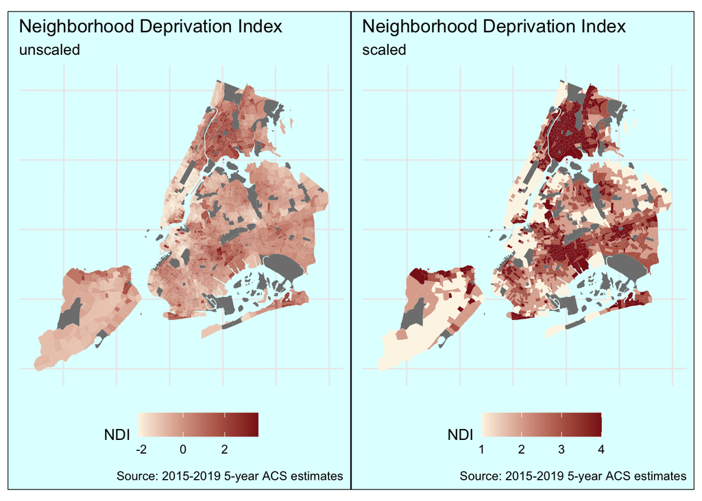

```r
map_ndi_with_score + map_ndi_with_scaled_score
```

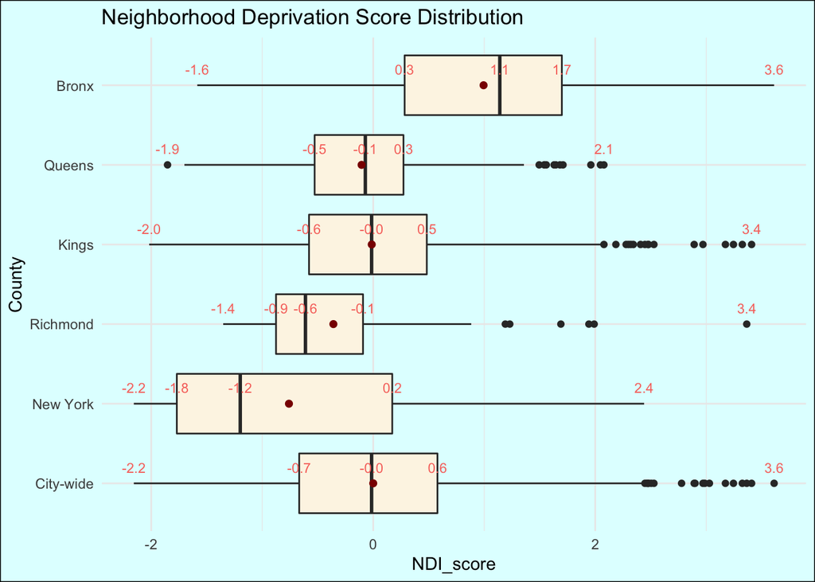

```r
City_score = NDI_2086 %>%
  select(NDI_score) %>%
  mutate(County = "City-wide")

Stratified = NDI_2086 %>%
  select(NDI_score, County)


NDI_box = rbind(City_score,Stratified)

NDI_box$County <- factor(NDI_box$County, levels=c("City-wide","New York", "Richmond","Kings", "Queens","Bronx"))



ggplot(NDI_box, aes(x = County, y = NDI_score))+
  geom_boxplot(fill = "OldLace") +
    stat_summary(
    aes(label=sprintf("%1.1f", ..y..), color = "red"),
    geom="text",
    fun = quantile,
    #fun = function(y) boxplot.stats(y)$stats,
    position=position_nudge(x=0.2),
    size=3.0, show.legend=FALSE)+
    stat_summary(fun=mean, colour="darkred", geom="point",
               shape=16, size=2, show.legend=FALSE)+
  coord_flip() +
  theme_minimal()+
  theme(plot.background = element_rect(fill = "lightcyan")) +
  labs(title = "Neighborhood Deprivation Score Distribution")
```

## SVI

Import the CDC SVI data file. The variable “RPL_THEMES” is the SVI.

```r
SDI_df = read_csv("data/raw/svi.csv") %>%
  mutate(FIPS = as.character(FIPS)) %>%
  filter(FIPS %in% NDI_2086$GEOID) %>%
  select(FIPS, LOCATION, COUNTY, RPL_THEMES) %>%
  rename(GEOID = FIPS) %>%
  filter(RPL_THEMES != -999.0000)
```

1. Scale the SVI in the same way as scaling the NDI. This scaled score will be used for future mapping
2. Conducted a spearman correlation test testing the association between the continouse NDI and SVI.

```r
SDI = scale(SDI_df$RPL_THEMES)

summary(SDI)
```

```
##        V1
##  Min.   :-2.3883
##  1st Qu.:-0.7615
##  Median : 0.1601
##  Mean   : 0.0000
##  3rd Qu.: 0.8513
##  Max.   : 1.4278
```

```r
SDI_df =
  data.frame(GEOID = SDI_df[,1], SDI)

SDI_scaled = SDI_df %>%
  dplyr::mutate(SDI_s = dplyr::ntile(SDI, 4))

summary(SDI_df)
```

```
##     GEOID                SDI
##  Length:2086        Min.   :-2.3883
##  Class :character   1st Qu.:-0.7615
##  Mode  :character   Median : 0.1601
##                     Mean   : 0.0000
##                     3rd Qu.: 0.8513
##                     Max.   : 1.4278
```

```r
NDI_c = join(NDI_2086, SDI_df, by = "GEOID") %>%
  pull(NDI_score) %>% as.numeric()

SDI_c = join(NDI_2086, SDI_df, by = "GEOID") %>%
  pull(SDI) %>% as.numeric()

cor.test(NDI_c, SDI_c, alternative = "two.sided", method = "spearman", conf.level = 0.95)
```

```
##
##  Spearman's rank correlation rho
##
## data:  NDI_c and SDI_c
## S = 203714718, p-value < 2.2e-16
## alternative hypothesis: true rho is not equal to 0
## sample estimates:
##       rho
## 0.8653424
```

The correlation coefficient between NDI and SVI is 0.86. They are correlated.

#### Visualization: Check the SVI distribution

```r
map_sdi = nyc_boundaries(geography = "tract") %>%
  left_join(SDI_df, by = c("geoid" = "GEOID")) %>%
  ggplot() +
  geom_sf(aes(fill = SDI),color = NA) +
  theme_minimal() +
  theme(axis.text = element_blank(),legend.position = "bottom") +
  scico::scale_fill_scico(palette = "bilbao") +
  theme(plot.background = element_rect(fill = "lightcyan")) +
  scale_fill_gradient(low = "White", high = "firebrick4")+
  labs(fill = "SDI",
       title = "Social Vulnerability Index",
       subtitle = "unscaled",
       caption = "Source: 2018 CDC/ATSDR SVI Data")
map_scaled_sdi = nyc_boundaries(geography = "tract") %>%
  left_join(SDI_scaled, by = c("geoid" = "GEOID")) %>%
  ggplot() +
  geom_sf(aes(fill = SDI_s),color = NA, ) +
  theme_minimal() +
  theme(axis.text = element_blank(),legend.position = "bottom") +
  theme(plot.background = element_rect(fill = "lightcyan")) +
  scico::scale_fill_scico(palette = "bilbao") +
  scale_fill_gradient(low = "OldLace", high = "firebrick4")+
  labs(fill = "SDI",
       title = "Social Vulnerability Index",
       subtitle = "scaled",
       caption = "Source: 2018 CDC/ATSDR SVI Data")
```

## NDI vs SVI Maps

[figure not shown]

```r
(map_ndi_with_score + map_sdi)/(map_ndi_with_scaled_score + map_scaled_sdi)
```

## Result analysis: First Component Loadings

In this section, we will check the county-specific and city-wide feature loadings on the first principal component.

```r
c_city_wide = pca_ndi_rotated$loadings[,1]

#pca_ndi_income$loadings[,1]
```

#### Bronx：First Component Loading

```r
Bronx=
  nyc_acs_data %>%
  filter(str_detect(GEOID, "^36005" )) %>%
  select(pct_BAmore,pct_unempl,pct_mgmt,pct_poverty,pct_under35K,pct_pubassist,pct_nonWhite)
```

```r
pca_Bronx_rotated <- psych::principal(Bronx, rotate="none", nfactors=1, scores=TRUE)
c_bronx = pca_Bronx_rotated$loadings[,1]
print(c_bronx)
```

```
##    pct_BAmore    pct_unempl      pct_mgmt   pct_poverty  pct_under35K
##     0.8912247     0.6230822     0.8497903     0.8880392     0.8936478
## pct_pubassist  pct_nonWhite
##     0.7693168     0.7925676
```

#### Kings

```r
Kings=
  nyc_acs_data %>%
  filter(str_detect(GEOID, "^36047" )) %>%
  select(pct_BAmore,pct_unempl,pct_mgmt,pct_poverty,pct_under35K,pct_pubassist,pct_nonWhite)
```

```r
pca_kings_rotated <- psych::principal(Kings, rotate="none", nfactors=1, scores=TRUE)
c_kings = pca_kings_rotated$loadings[,1]
print(c_kings)
```

```
##    pct_BAmore    pct_unempl      pct_mgmt   pct_poverty  pct_under35K
##     0.8635977     0.5271729     0.8145213     0.7906005     0.8594067
## pct_pubassist  pct_nonWhite
##     0.7414879     0.6265817
```

#### NY

```r
NY=
  nyc_acs_data %>%
  filter(str_detect(GEOID, "^36061" )) %>%
  select(pct_BAmore,pct_unempl,pct_mgmt,pct_poverty,pct_under35K,pct_pubassist,pct_nonWhite)
```

```r
pca_ny_rotated <- psych::principal(NY, rotate="none", nfactors=1, scores=TRUE)
c_ny = pca_ny_rotated$loadings[,1]
print(c_ny)
```

```
##    pct_BAmore    pct_unempl      pct_mgmt   pct_poverty  pct_under35K
##     0.9678196     0.5928540     0.9205011     0.9136955     0.9455561
## pct_pubassist  pct_nonWhite
##     0.8447637     0.9364677
```

#### Queens

```r
Queens=
  nyc_acs_data %>%
  filter(str_detect(GEOID, "^36081" )) %>%
  select(pct_BAmore,pct_unempl,pct_mgmt,pct_poverty,pct_under35K,pct_pubassist,pct_nonWhite)
```

```r
pca_queens_rotated <- psych::principal(Queens, rotate="none", nfactors=1, scores=TRUE)
c_queens = pca_queens_rotated$loadings[,1]
print(c_queens)
```

```
##    pct_BAmore    pct_unempl      pct_mgmt   pct_poverty  pct_under35K
##     0.8427162     0.4396688     0.8222197     0.6476706     0.5762765
## pct_pubassist  pct_nonWhite
##     0.6032032     0.7472671
```

#### Richmond

```r
Richmond=
  nyc_acs_data %>%
  filter(str_detect(GEOID, "^36085" )) %>%
  select(pct_BAmore,pct_unempl,pct_mgmt,pct_poverty,pct_under35K,pct_pubassist,pct_nonWhite)
#values_Richmond[values_Richmond == 0] <- NA
```

```r
pca_richmond_rotated <- psych::principal(Richmond, rotate="none", nfactors=1, scores=TRUE)
c_richmond = pca_richmond_rotated$loadings[,1]
print(c_richmond)
```

```
##    pct_BAmore    pct_unempl      pct_mgmt   pct_poverty  pct_under35K
##     0.7674728     0.2346507     0.7086721     0.9257778     0.9043481
## pct_pubassist  pct_nonWhite
##     0.8953824     0.8581273
```

```r
r_prop_var = c(67.4,55.8,79.1,48.9,64.2,61.4)
```

#### Comparison Table: First Component Loadings

```r
library(knitr)
```

```r
df = data.frame(c_bronx,c_kings,c_ny,c_queens,c_richmond, c_city_wide) %>% rbind(r_prop_var)
new_df = as.data.frame(lapply(df,round, 3))
```

```r
df1 = round(max(df[1,]) - min(df[1,]), digits = 3)
df2 = round(max(df[2,]) - min(df[2,]), digits = 3)
df3 = round(max(df[3,]) - min(df[3,]), digits = 3)
df4 = round(max(df[4,]) - min(df[4,]), digits = 3)
df5 = round(max(df[5,]) - min(df[5,]), digits = 3)
df6 = round(max(df[6,]) - min(df[6,]), digits = 3)
df7 = round(max(df[7,]) - min(df[7,]), digits = 3)


difference = c(df1,df2,df3,df4,df5,df6,df7," ")

loading_comparison = new_df %>% cbind(difference)
row.names(loading_comparison) = c("% B.S./B.A. or higher","% Unempolyment", "% Management Occupation",
                                  "% Households in Poverty","% Households with annual income < $35,000",
                                  "% Households receving public assistance",
                                  "% Non-Hispanic non-White", "% Variance Explained")
colnames(loading_comparison) = c("Bronx","Kings","New York", "Queens", "Richmond","City-wide Index","Loading Difference")

loading_comparison %>% kable(caption = "Supplemental Table 3. Comparison of Borough-specific and City-wide first principal component deprivation score loadings")
```

Supplemental Table 3. Comparison of Borough-specific and City-wide first principal component deprivation score loadings

|  | Bronx | Kings | New York | Queens | Richmond | City-wide Index | Loading Difference |
| --- | --- | --- | --- | --- | --- | --- | --- |
| % B.S./B.A. or higher | 0.891 | 0.864 | 0.968 | 0.843 | 0.767 | 0.853 | 0.2 |
| % Unempolyment | 0.623 | 0.527 | 0.593 | 0.440 | 0.235 | 0.606 | 0.388 |
| % Management Occupation | 0.850 | 0.815 | 0.921 | 0.822 | 0.709 | 0.820 | 0.212 |
| % Households in Poverty | 0.888 | 0.791 | 0.914 | 0.648 | 0.926 | 0.819 | 0.278 |
| % Households with annual income < $35,000 | 0.894 | 0.859 | 0.946 | 0.576 | 0.904 | 0.840 | 0.369 |
| % Households receving public assistance | 0.769 | 0.741 | 0.845 | 0.603 | 0.895 | 0.769 | 0.292 |
| % Non-Hispanic non-White | 0.793 | 0.627 | 0.936 | 0.747 | 0.858 | 0.744 | 0.31 |
| % Variance Explained | 67.400 | 55.800 | 79.100 | 48.900 | 64.200 | 61.400 |  |

This result is save as the Supplemental table 3 in the manualscript.